# Publication-Quality Visualization with R

Workshop Code-Along — R-Only Edition (for RStudio)

Yuyan Yi

December 4, 2026

> **This is the R-only version of the workshop materials**, for attendees using RStudio without a Python kernel available. A separate Jupyter notebook version exists for Python-only attendees. A combined Quarto document (R + Python side by side) is also available for anyone running Positron with both languages configured.

## Setup

### R packages needed

```r
install.packages(c(
  "tidyverse", "survival", "survminer", "patchwork",
  "ggpubr", "viridis", "forestplot", "gtsummary", "gt",
  "table1", "ggridges", "pROC", "svglite"
))
```

## 1. Generate Synthetic Clinical Data

We’ll simulate a small clinical trial dataset: patient demographics, a biomarker, treatment arm, a continuous lab outcome, and survival/censoring data. This mirrors the shape of real trial data without using any real patient information.

**Sample size:** 200 simulated patients

[output not shown]

Two companion datasets are generated later in the document: `longitudinal_data.csv` (same 200 patients, measured at 4 visits — week 0, 4, 8, 12) and `pca_data.csv` (same 200 patients with 6 synthetic correlated biomarkers, marker_1-marker_6).

```r
library(tidyverse)
set.seed(42)

n <- 200

clinical_r <- tibble(
  patient_id = sprintf("PT-%03d", 1:n),
  arm = sample(c("Control", "Treatment"), n, replace = TRUE),
  age = round(rnorm(n, mean = 58, sd = 12)),
  sex = sample(c("Female", "Male"), n, replace = TRUE, prob = c(0.52, 0.48)),
  site = sample(paste0("Site_", 1:4), n, replace = TRUE),
  smoker = sample(c("Never", "Former", "Current"), n, replace = TRUE, prob = c(0.5, 0.3, 0.2)),
  biomarker = rgamma(n, shape = 2, scale = 15),
  baseline_score = rnorm(n, mean = 50, sd = 10)
) %>%
  mutate(
    # Site-level effect baked in so the ANOVA/pairwise comparisons section
    # has something real to find -- Site_3 runs noticeably lower than the
    # others, Site_1/2/4 are similar to each other.
    site_effect = case_when(
      site == "Site_3" ~ -9,
      TRUE ~ 0
    ),
    followup_score = baseline_score -
      ifelse(arm == "Treatment", rnorm(n, 8, 5), rnorm(n, 1, 5)) +
      site_effect,
    responder = ifelse(
      arm == "Treatment",
      rbinom(n, 1, 0.55),
      rbinom(n, 1, 0.30)
    ),
    response_label = factor(responder, labels = c("No Response", "Response")),
    time_months = pmax(
      1,
      rexp(n, rate = 1 / (24 + ifelse(arm == "Treatment", 8, 0) - (age - 58) * 0.2))
    ),
    event = rbinom(n, 1, prob = 0.65)
  ) %>%
  select(-site_effect)

write_csv(clinical_r, "clinical_trial_data.csv")
head(clinical_r)
```

```
## # A tibble: 6 × 13
##   patient_id arm         age sex    site   smoker  biomarker baseline_score
##   <chr>      <chr>     <dbl> <chr>  <chr>  <chr>       <dbl>          <dbl>
## 1 PT-001     Control      72 Female Site_4 Current     18.2            62.6
## 2 PT-002     Control      71 Female Site_2 Never        8.93           53.3
## 3 PT-003     Control      46 Male   Site_2 Current     40.5            62.9
## 4 PT-004     Control      80 Female Site_1 Former      12.0            50.0
## 5 PT-005     Treatment    50 Female Site_2 Never       76.6            57.8
## 6 PT-006     Treatment    59 Female Site_4 Never       17.3            55.7
## # ℹ 5 more variables: followup_score <dbl>, responder <int>,
## #   response_label <fct>, time_months <dbl>, event <int>
```

### Longitudinal data (for line chart section)

```r
visits <- c(0, 4, 8, 12)

longitudinal_r <- clinical_r %>%
  select(patient_id, arm) %>%
  crossing(week = visits) %>%
  arrange(patient_id, week) %>%
  group_by(patient_id) %>%
  mutate(
    arm_effect = ifelse(first(arm) == "Treatment", -1.8, -0.3),
    score = 50 + arm_effect * week + rnorm(n(), 0, 4)
  ) %>%
  ungroup() %>%
  select(patient_id, arm, week, score)

write_csv(longitudinal_r, "longitudinal_data.csv")
head(longitudinal_r, 8)
```

```
## # A tibble: 8 × 4
##   patient_id arm      week score
##   <chr>      <chr>   <dbl> <dbl>
## 1 PT-001     Control     0  42.0
## 2 PT-001     Control     4  43.6
## 3 PT-001     Control     8  49.1
## 4 PT-001     Control    12  45.8
## 5 PT-002     Control     0  47.1
## 6 PT-002     Control     4  45.7
## 7 PT-002     Control     8  49.8
## 8 PT-002     Control    12  40.0
```

## 2. Choosing the Right Visualization

Before writing any code, the most important decision is: *what type of data do I have, and what question am I asking of it?* Use this as a decision reference, not a rulebook — there are always exceptions, but these are solid defaults.

### Quick decision table

| Data type | Question being asked | Recommended plot |
| --- | --- | --- |
| Continuous, 1 group | Distribution shape | Histogram, density plot |
| Continuous, 2 groups | Compare distributions | Boxplot + jitter, violin plot |
| Continuous, 3+ groups | Compare distributions | Boxplot/violin faceted or grouped |
| Continuous, paired/matched | Change within subject | Paired line plot (spaghetti plot) |
| Continuous x continuous | Relationship/correlation | Scatter plot (+ trend line) |
| Continuous over time | Trend / trajectory | Line chart (mean +/- SE/SD) |
| Time-to-event (censored) | Survival/time-to-event | Kaplan-Meier curve |
| Categorical x categorical | Association/proportions | Stacked or grouped bar, mosaic plot |
| Categorical, 1 variable | Counts/frequency | Bar chart |
| Effect sizes across subgroups | Compare estimates + CIs | Forest plot |
| High-dimensional (many genes/features) | Structure, clustering, batch effects | PCA/UMAP scatter, heatmap |

### Worked examples

**Boxplot** — comparing a lab value (continuous) across 2-4 treatment arms (categorical). The box shows median and IQR, whiskers show range, and adding jittered points shows actual sample size and skew/bimodality that the box alone can hide. Usually a better default than a bar chart of group means, since a bar+error bar can look identical for very different underlying distributions.

**Bar chart** — for counts/proportions of categorical data, or a mean with an important caveat: a bar chart of means can be misleading since it visually implies the data starts at zero. If using mean ± SD/SE bars, always overlay individual data points.

**Histogram** — to see the full distribution shape of one continuous variable, e.g. checking normality before choosing a t-test vs. Wilcoxon test.

**Scatter plot** — for two continuous variables and a relationship. Also the right plot for **PCA results** (PC1 vs PC2), where axes need a “% variance explained” label since they’re composite constructed dimensions, not original measured variables.

**Line chart** — for repeated measurements over an ordered variable (almost always time). Only connect points with real ordering.

**Kaplan-Meier curve** — specifically for time-to-event data with censoring. Never substitute a boxplot of raw “time to event” values.

**Forest plot** — to compare an effect size and CI across several subgroups at once; preferred over a table of numbers for more than ~4-5 subgroups.

**Stacked/grouped bar chart** — for categorical x categorical data. Use *stacked* for 2-3 categories where you care about the whole; use *grouped* when you want precise comparison of one category across groups.

**Heatmap** — for high-dimensional continuous data (e.g., gene expression, correlation matrices). Pair with hierarchical clustering, and use a diverging colormap if there’s a meaningful zero point.

## 3. Plot Parameters: A Quick Reference

### Quick reference table

| Parameter | ggplot2 | Typical publication value |
| --- | --- | --- |
| Point size | `size =` in `geom_point()` | 2-4 (small multi-panel), 4-8 (single figure) |
| Point shape/type | `shape =` (0-25, numeric codes) | Keep consistent per group across a paper |
| Point/line transparency | `alpha =` (0-1) | 0.5-0.8 overlapping points; 1.0 for lines |
| Line type | `linetype =` (‘solid’,‘dashed’,‘dotted’) | Solid for primary data, dashed for reference |
| Line width | `linewidth =` (ggplot2 >= 3.4) | 0.5-1 gridlines, 1.5-2.5 data lines |
| Figure size | `ggsave(width=, height=, units="in")` | ~3.5in (1-col) or ~7in (2-col) journal width |
| Font size (base) | `theme_minimal(base_size = 12)` | 8-10pt at final print size |
| Legend position | `theme(legend.position = "top"/"right"/"none")` | “none” if 1 group; “right”/“top” for 2+ |
| DPI (export) | `ggsave(dpi = 300)` | 300 minimum; 600 for line art |

### Worked example: the same scatter plot, three parameter presets

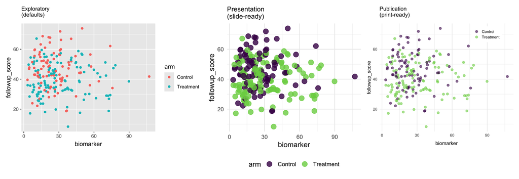

```r
library(patchwork)

preset_exploratory <- ggplot(clinical_r, aes(biomarker, followup_score, color = arm)) +
  geom_point() +
  labs(title = "Exploratory\n(defaults)") +
  theme(plot.title = element_text(size = 10))

preset_presentation <- ggplot(clinical_r, aes(biomarker, followup_score, color = arm)) +
  geom_point(size = 4, alpha = 0.8) +
  scale_color_viridis_d(end = 0.8) +
  labs(title = "Presentation\n(slide-ready)") +
  theme_minimal(base_size = 13) +
  theme(legend.position = "bottom", plot.title = element_text(size = 12))

preset_publication <- ggplot(clinical_r, aes(biomarker, followup_score, color = arm)) +
  geom_point(size = 1.8, alpha = 0.6) +
  scale_color_viridis_d(end = 0.8) +
  labs(title = "Publication\n(print-ready)", color = NULL) +
  theme_minimal(base_size = 9) +
  theme(
    plot.title = element_text(size = 10),
    legend.position = "inside",
    legend.position.inside = c(0.8, 0.9),
    legend.background = element_rect(fill = "white", color = NA),
    legend.key.size = unit(0.35, "cm"),
    legend.text = element_text(size = 7)
  )

# patchwork's | operator places separate ggplot objects side-by-side
preset_exploratory | preset_presentation | preset_publication
```

> **A note on the legend choice above:** some publication figures drop the legend entirely, relying on the caption to explain colors. That can be a confusing default for a teaching example, since without a legend a reader has no way to know what each color means — so the publication preset here keeps a compact, in-plot legend rather than removing it.

### A note on consistency across a paper

Define your preset once as a reusable theme, and apply it everywhere:

```r
my_pub_theme <- theme_minimal(base_size = 9) + theme(legend.position = "none")
ggplot(clinical_r, aes(biomarker, followup_score)) + geom_point(size = 1.8, alpha = 0.6) + my_pub_theme
```

## 4. Table 1: Summary Statistics with Group Comparison Tests

- **Continuous variables**: t-test or Wilcoxon/Mann-Whitney
- **Categorical variables**: chi-square, or Fisher’s exact when expected cell counts are small

### gtsummary (recommended)

```r
library(gtsummary)

clinical_r %>%
  select(arm, age, sex, smoker, biomarker, response_label) %>%
  tbl_summary(
    by = arm,
    statistic = list(
      all_continuous() ~ "{mean} ({sd})",
      all_categorical() ~ "{n} ({p}%)"
    ),
    digits = all_continuous() ~ 1
  ) %>%
  add_p(
    test = list(
      all_continuous() ~ "t.test",
      all_categorical() ~ "chisq.test"
    )
  ) %>%
  add_overall() %>%
  bold_labels()
```

| **Characteristic** | **Overall** N = 200<sup>1</sup> | **Control** N = 89<sup>1</sup> | **Treatment** N = 111<sup>1</sup> | **p-value**<sup>2</sup> |
| --- | --- | --- | --- | --- |
| age | 57.4 (11.5) | 57.1 (11.2) | 57.7 (11.8) | 0.7 |
| sex |  |  |  | 0.8 |
| Female | 107 (54%) | 46 (52%) | 61 (55%) |  |
| Male | 93 (47%) | 43 (48%) | 50 (45%) |  |
| smoker |  |  |  | 0.7 |
| Current | 42 (21%) | 18 (20%) | 24 (22%) |  |
| Former | 54 (27%) | 22 (25%) | 32 (29%) |  |
| Never | 104 (52%) | 49 (55%) | 55 (50%) |  |
| biomarker | 29.2 (19.2) | 26.9 (17.3) | 31.1 (20.5) | 0.12 |
| response_label |  |  |  | 0.003 |
| No Response | 110 (55%) | 60 (67%) | 50 (45%) |  |
| Response | 90 (45%) | 29 (33%) | 61 (55%) |  |

<sup>1</sup> Mean (SD); n (%)  
<sup>2</sup> Welch Two Sample t-test; Pearson’s Chi-squared test

### Manual approach (full control over which test runs)

```r
t_test_age <- t.test(age ~ arm, data = clinical_r)
wilcox_biomarker <- wilcox.test(biomarker ~ arm, data = clinical_r)

sex_table <- table(clinical_r$sex, clinical_r$arm)
chisq_check <- chisq.test(sex_table)
if (any(chisq_check$expected < 5)) {
  sex_test <- fisher.test(sex_table)
  sex_test_name <- "Fisher's exact"
} else {
  sex_test <- chisq_check
  sex_test_name <- "Chi-square"
}

cat("Age t-test p-value:", round(t_test_age$p.value, 4), "\n")
```

```
## Age t-test p-value: 0.7192
```

```r
cat("Biomarker Wilcoxon p-value:", round(wilcox_biomarker$p.value, 4), "\n")
```

```
## Biomarker Wilcoxon p-value: 0.2783
```

```r
cat("Sex test used:", sex_test_name, "- p-value:", round(sex_test$p.value, 4), "\n")
```

```
## Sex test used: Chi-square - p-value: 0.7504
```

> **Teaching note:** chi-square needs expected cell counts >= 5 in every cell to be reliable; below that, switch to Fisher’s exact.

## 5. Grammar of Graphics — Scatter Plot

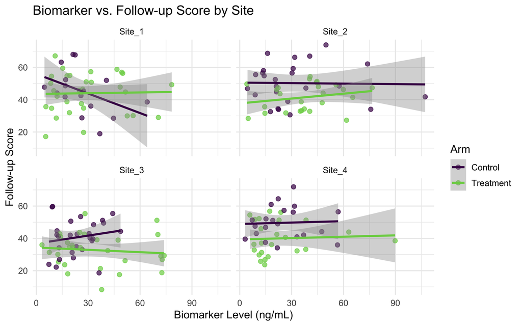

```r
library(viridis)

ggplot(clinical_r, aes(x = biomarker, y = followup_score, color = arm)) +
  geom_point(alpha = 0.7, size = 2) +
  geom_smooth(method = "lm", se = TRUE) +
  facet_wrap(~site) +
  scale_color_viridis_d(end = 0.8) +
  labs(
    x = "Biomarker Level (ng/mL)",
    y = "Follow-up Score",
    color = "Arm",
    title = "Biomarker vs. Follow-up Score by Site"
  ) +
  theme_minimal(base_size = 12)
```

## 6. Line Chart — Longitudinal / Repeated Measures

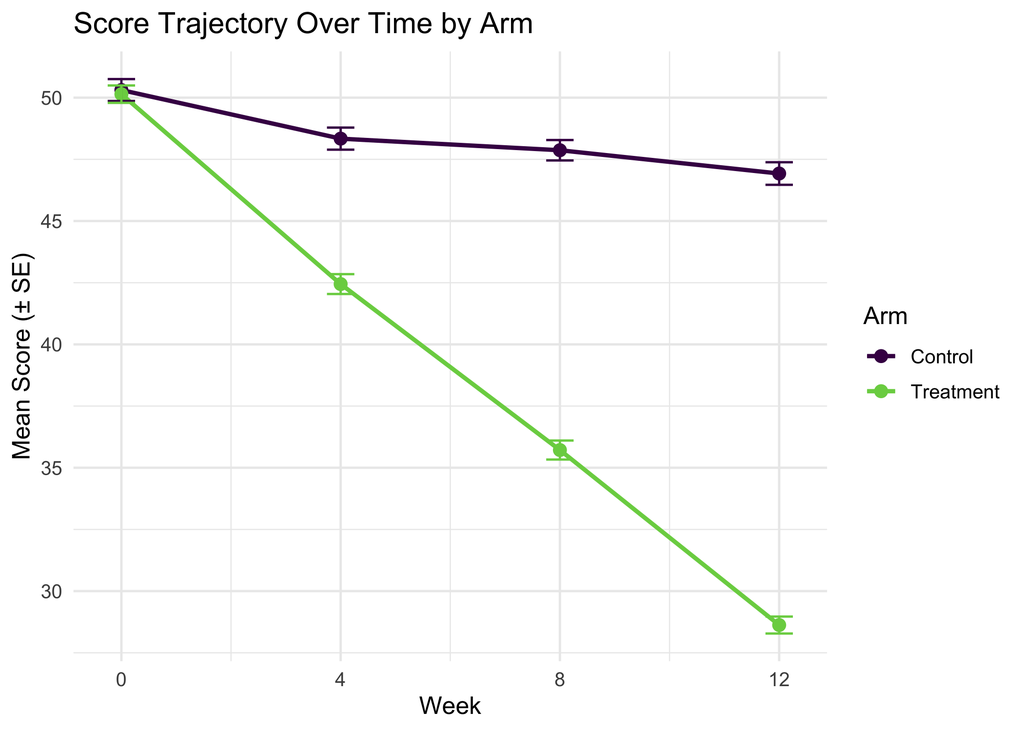

```r
summary_r <- longitudinal_r %>%
  group_by(arm, week) %>%
  summarise(
    mean_score = mean(score),
    sd_score = sd(score),
    se_score = sd_score / sqrt(n()),
    .groups = "drop"
  )

ggplot(summary_r, aes(x = week, y = mean_score, color = arm, group = arm)) +
  geom_line(linewidth = 1) +
  geom_point(size = 2.5) +
  geom_errorbar(
    aes(ymin = mean_score - se_score, ymax = mean_score + se_score),
    width = 0.5
  ) +
  scale_color_viridis_d(end = 0.8) +
  labs(
    x = "Week", y = "Mean Score (\u00b1 SE)", color = "Arm",
    title = "Score Trajectory Over Time by Arm"
  ) +
  theme_minimal(base_size = 12)
```

> **Teaching note:** SD describes spread of individual observations; SE describes uncertainty in the mean and shrinks as sample size grows. Always label which one you plotted.

## 7. Density Plots

### 7.1 Single density plot

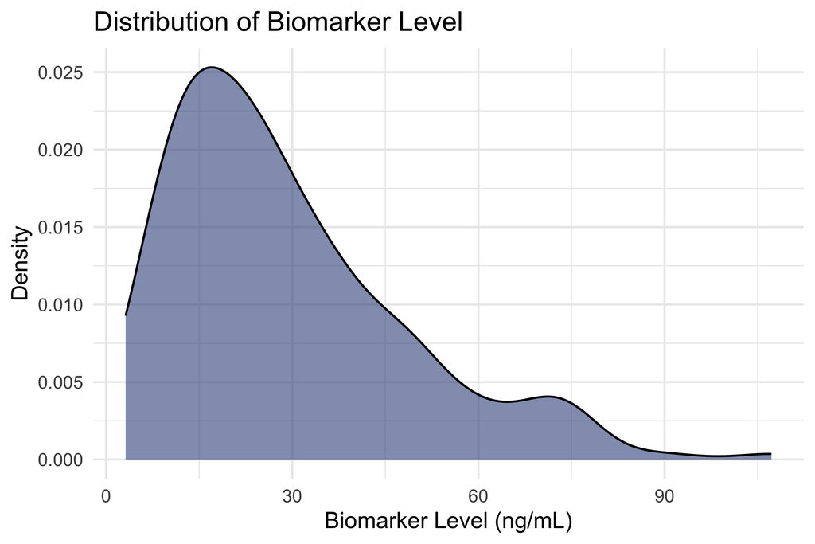

```r
ggplot(clinical_r, aes(x = biomarker)) +
  geom_density(fill = "#3b528b", alpha = 0.6) +
  labs(x = "Biomarker Level (ng/mL)", y = "Density", title = "Distribution of Biomarker Level") +
  theme_minimal(base_size = 12)
```

### 7.2 Multiple-group overlaid density plot

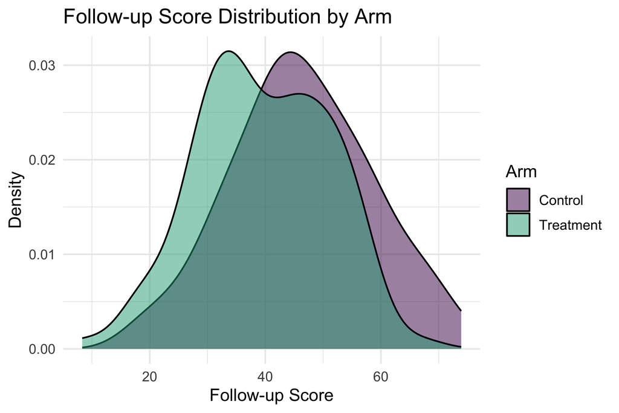

```r
ggplot(clinical_r, aes(x = followup_score, fill = arm)) +
  geom_density(alpha = 0.5) +
  scale_fill_viridis_d(end = 0.6) +
  labs(x = "Follow-up Score", y = "Density", fill = "Arm",
       title = "Follow-up Score Distribution by Arm") +
  theme_minimal(base_size = 12)
```

### 7.3 Ridgeline plot (many groups)

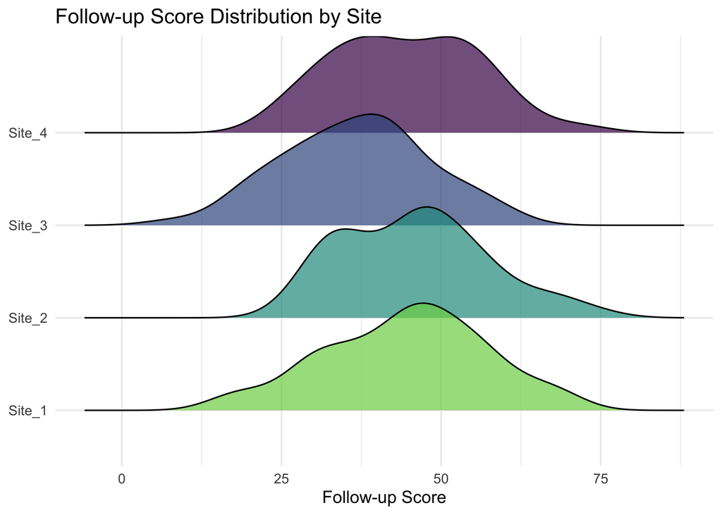

```r
library(ggridges)

ggplot(clinical_r, aes(x = followup_score, y = site, fill = site)) +
  geom_density_ridges(alpha = 0.7, scale = 1.2) +
  scale_fill_viridis_d(end = 0.8, direction = -1) +
  labs(x = "Follow-up Score", y = NULL, title = "Follow-up Score Distribution by Site") +
  theme_minimal(base_size = 12) +
  theme(legend.position = "none")
```

## 8. Kaplan-Meier Survival Curve

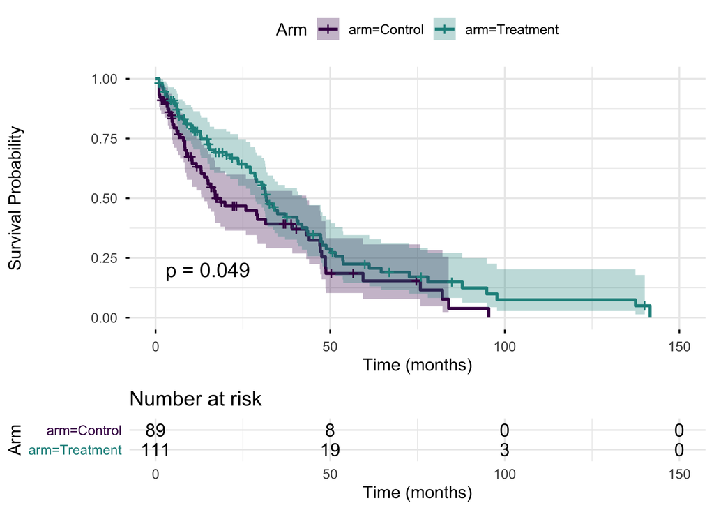

```r
library(survival)
library(survminer)

fit <- survfit(Surv(time_months, event) ~ arm, data = clinical_r)

ggsurvplot(
  fit,
  data = clinical_r,
  pval = TRUE,
  conf.int = TRUE,
  risk.table = TRUE,
  palette = c("#440154", "#21908C"),
  xlab = "Time (months)",
  ylab = "Survival Probability",
  legend.title = "Arm",
  ggtheme = theme_minimal(base_size = 12)
)
```

## 9. Forest Plot (Effect Sizes)

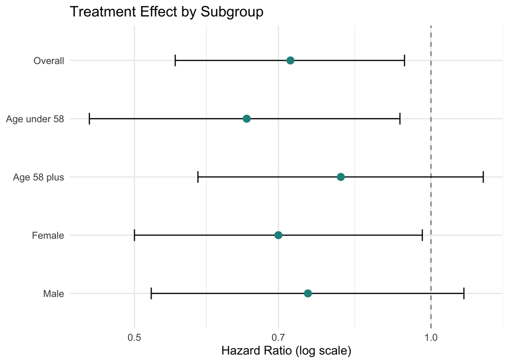

```r
forest_data_r <- tibble(
  subgroup = c("Overall", "Age under 58", "Age 58 plus", "Female", "Male"),
  hr = c(0.72, 0.65, 0.81, 0.70, 0.75),
  lower = c(0.55, 0.45, 0.58, 0.50, 0.52),
  upper = c(0.94, 0.93, 1.13, 0.98, 1.08)
) %>%
  mutate(subgroup = fct_rev(fct_inorder(subgroup)))

ggplot(forest_data_r, aes(x = hr, y = subgroup)) +
  geom_vline(xintercept = 1, linetype = "dashed", color = "gray50") +
  geom_errorbarh(aes(xmin = lower, xmax = upper), height = 0.2) +
  geom_point(size = 3, color = "#21908C") +
  scale_x_log10() +
  labs(
    x = "Hazard Ratio (log scale)", y = NULL,
    title = "Treatment Effect by Subgroup"
  ) +
  theme_minimal(base_size = 12)
```

> Hazard ratios are plotted on a log scale so that a doubling (HR=2) and a halving (HR=0.5) of risk sit at equal visual distances from the null line at HR=1.

## 10. ROC Curve and AUC

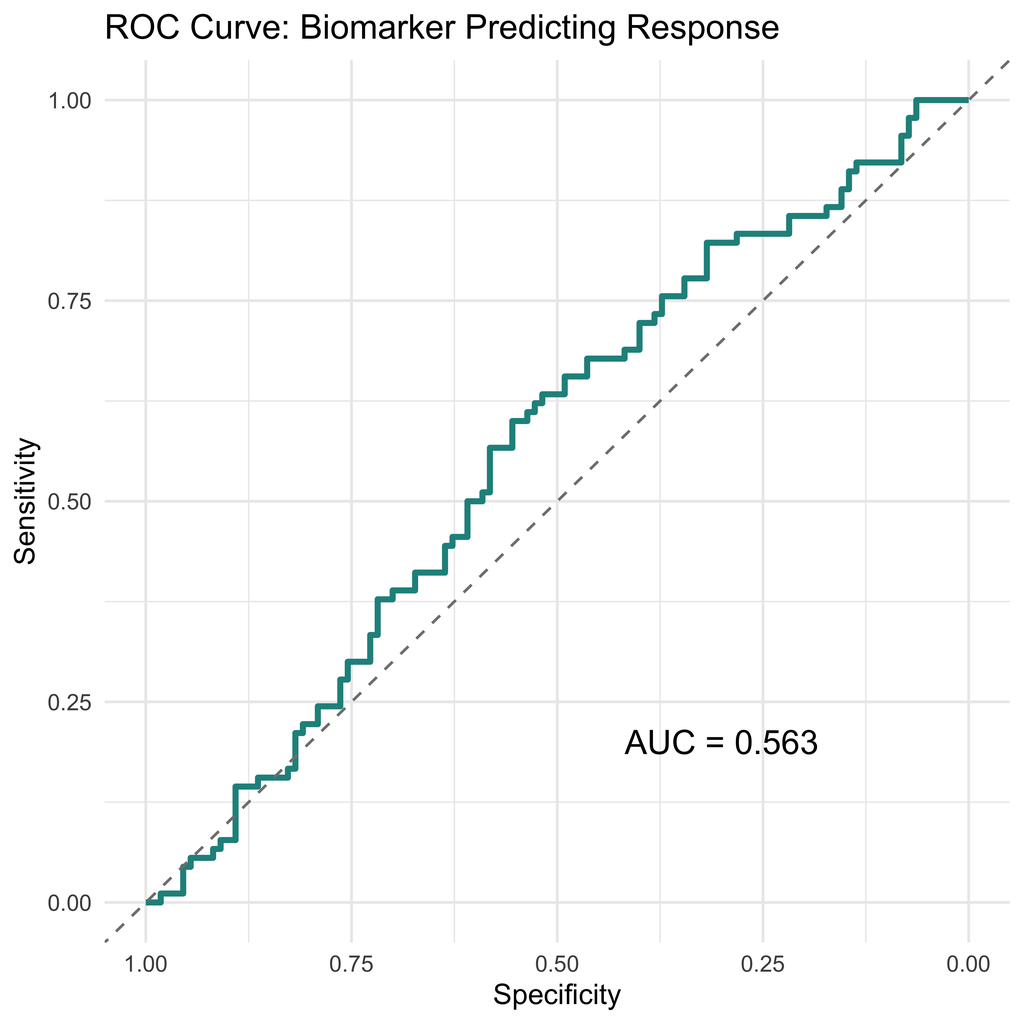

```r
library(pROC)

roc_obj_r <- roc(clinical_r$responder, clinical_r$biomarker, quiet = TRUE)
auc_val_r <- auc(roc_obj_r)

ggroc(roc_obj_r, color = "#21908C", linewidth = 1.2) +
  geom_abline(slope = 1, intercept = 1, linetype = "dashed", color = "gray50") +
  annotate("text", x = 0.3, y = 0.2, label = sprintf("AUC = %.3f", auc_val_r), size = 5) +
  labs(x = "Specificity", y = "Sensitivity", title = "ROC Curve: Biomarker Predicting Response") +
  theme_minimal(base_size = 12)
```

> **Teaching note:** AUC alone doesn’t tell you where to set a decision threshold for clinical use — that requires weighing the relative cost of false positives vs. false negatives in your specific clinical context.

## 11. Boxplot Variants with Statistical Annotation

### 11.1 Boxplot with jitter

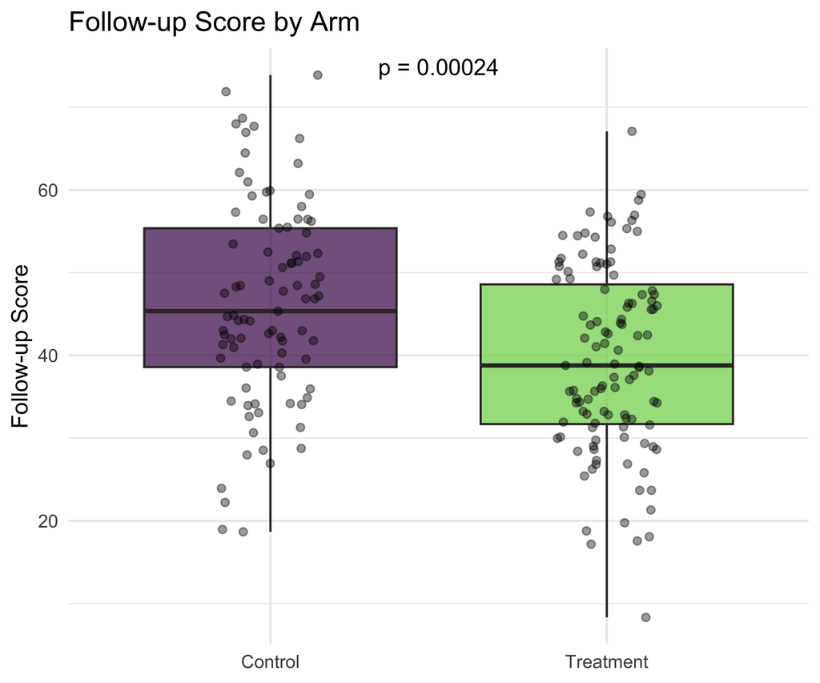

```r
library(ggpubr)

ggplot(clinical_r, aes(x = arm, y = followup_score, fill = arm)) +
  geom_boxplot(alpha = 0.7, outlier.shape = NA) +
  geom_jitter(width = 0.15, alpha = 0.4) +
  stat_compare_means(
    method = "wilcox.test", label = "p.format",
    label.x = 1.5, hjust = 0.5
  ) +
  scale_fill_viridis_d(end = 0.8) +
  labs(x = NULL, y = "Follow-up Score", title = "Follow-up Score by Arm") +
  theme_minimal(base_size = 12) +
  theme(legend.position = "none")
```

### 11.2 Mean +/- SD bar chart with significance stars

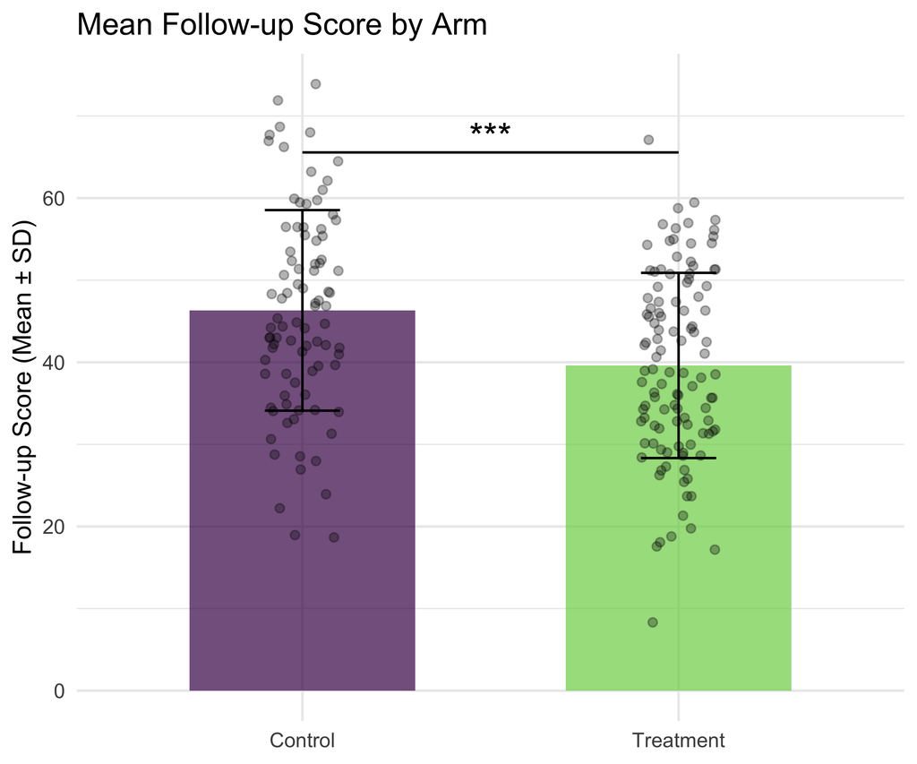

```r
summary_stats_r <- clinical_r %>%
  group_by(arm) %>%
  summarise(mean_val = mean(followup_score), sd_val = sd(followup_score), .groups = "drop")

test_result_r <- wilcox.test(followup_score ~ arm, data = clinical_r)
p_val_r <- test_result_r$p.value

stars_r <- case_when(
  p_val_r < 0.001 ~ "***",
  p_val_r < 0.01  ~ "**",
  p_val_r < 0.05  ~ "*",
  TRUE            ~ "ns"
)

y_bracket <- max(summary_stats_r$mean_val + summary_stats_r$sd_val) * 1.12

ggplot(summary_stats_r, aes(x = arm, y = mean_val, fill = arm)) +
  geom_col(alpha = 0.7, width = 0.6) +
  geom_errorbar(aes(ymin = mean_val - sd_val, ymax = mean_val + sd_val), width = 0.2) +
  geom_jitter(data = clinical_r, aes(x = arm, y = followup_score),
              width = 0.1, alpha = 0.3, inherit.aes = FALSE) +
  annotate("segment", x = 1, xend = 2, y = y_bracket, yend = y_bracket) +
  annotate("text", x = 1.5, y = y_bracket * 1.03, label = stars_r, size = 6) +
  scale_fill_viridis_d(end = 0.8) +
  labs(x = NULL, y = "Follow-up Score (Mean \u00b1 SD)", title = "Mean Follow-up Score by Arm") +
  theme_minimal(base_size = 12) +
  theme(legend.position = "none")
```

> Thresholds: `*` p<0.05, `**` p<0.01, `***` p<0.001, `ns` not significant. State these explicitly in your figure legend regardless of which convention you use.

> **Note on the synthetic data:** `Site_3` has a deliberately engineered lower average `followup_score` baked into Section 1’s data generation, so this example has something significant to find. In your own real data you won’t know the answer in advance — that’s the point of running the test.

```r
anova_model <- aov(followup_score ~ site, data = clinical_r)
anova_summary <- summary(anova_model)
anova_pvalue <- anova_summary[[1]][1, "Pr(>F)"]
cat("ANOVA p-value:", format.pval(anova_pvalue, digits = 4), "\n")
```

```
## ANOVA p-value: 0.0001391
```

```r
tukey_result <- TukeyHSD(anova_model)
print(tukey_result)
```

```
##   Tukey multiple comparisons of means
##     95% family-wise confidence level
##
## Fit: aov(formula = followup_score ~ site, data = clinical_r)
##
## $site
##                      diff        lwr       upr     p adj
## Site_2-Site_1  1.45001761  -4.600979  7.501014 0.9252842
## Site_3-Site_1 -7.85262526 -13.740993 -1.964257 0.0037320
## Site_4-Site_1  0.07332795  -6.141827  6.288483 0.9999897
## Site_3-Site_2 -9.30264287 -15.159522 -3.445764 0.0003293
## Site_4-Site_2 -1.37668966  -7.562020  4.808640 0.9389513
## Site_4-Site_3  7.92595321   1.899625 13.952281 0.0043829
```

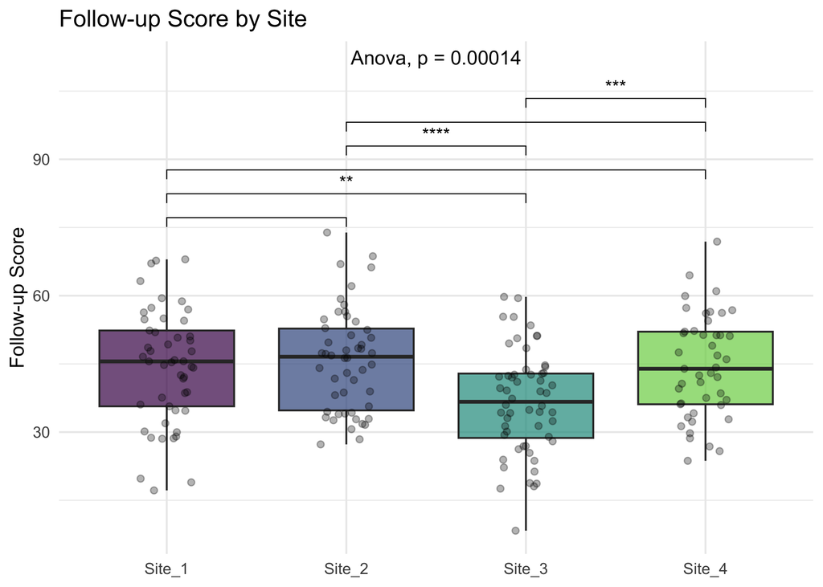

```r
site_levels <- levels(factor(clinical_r$site))
comparisons_list <- combn(site_levels, 2, simplify = FALSE)

ggplot(clinical_r, aes(x = site, y = followup_score, fill = site)) +
  geom_boxplot(alpha = 0.7, outlier.shape = NA) +
  geom_jitter(width = 0.15, alpha = 0.3) +
  stat_compare_means(
    method = "anova",
    label.y = max(clinical_r$followup_score) * 1.5,
    label.x = (length(site_levels) + 1) / 2,
    hjust = 0.5
  ) +
  stat_compare_means(
    comparisons = comparisons_list, method = "t.test",
    label = "p.signif", step.increase = 0.08, hide.ns = TRUE
  ) +
  scale_fill_viridis_d(end = 0.8) +
  labs(x = NULL, y = "Follow-up Score", title = "Follow-up Score by Site") +
  theme_minimal(base_size = 12) +
  theme(legend.position = "none")
```

## 12. Stacked Bar Plot (Categorical Proportions)

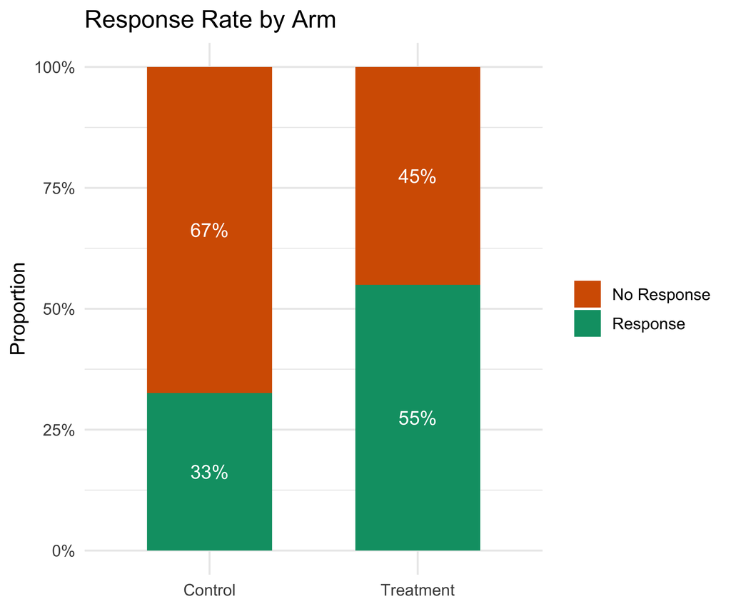

```r
response_summary_r <- clinical_r %>%
  count(arm, response_label) %>%
  group_by(arm) %>%
  mutate(prop = n / sum(n))

ggplot(response_summary_r, aes(x = arm, y = prop, fill = response_label)) +
  geom_col(position = "stack", width = 0.6) +
  geom_text(aes(label = scales::percent(prop, accuracy = 1)),
            position = position_stack(vjust = 0.5), color = "white", size = 4) +
  scale_fill_manual(values = c("#D55E00", "#009E73")) +
  scale_y_continuous(labels = scales::percent) +
  labs(x = NULL, y = "Proportion", fill = NULL, title = "Response Rate by Arm") +
  theme_minimal(base_size = 12)
```

## 13. PCA: Principal Component Plot and Biplot

```r
set.seed(7)
n_biomarkers <- 6
biomarker_names <- paste0("marker_", 1:n_biomarkers)

latent_factor <- rnorm(n)
arm_shift <- ifelse(clinical_r$arm == "Treatment", 1.2, -1.2)

pca_data_r <- clinical_r %>%
  select(patient_id, arm, site) %>%
  bind_cols(
    map_dfc(1:n_biomarkers, function(i) {
      tibble(!!biomarker_names[i] := latent_factor * runif(1, 0.4, 0.9) +
               arm_shift * runif(1, 0.2, 0.6) +
               rnorm(n, 0, 1))
    })
  )

write_csv(pca_data_r, "pca_data.csv")
head(pca_data_r)
```

```
## # A tibble: 6 × 9
##   patient_id arm     site  marker_1 marker_2 marker_3 marker_4 marker_5 marker_6
##   <chr>      <chr>   <chr>    <dbl>    <dbl>    <dbl>    <dbl>    <dbl>    <dbl>
## 1 PT-001     Control Site…    2.34     0.682  0.672     -0.128    1.47     0.217
## 2 PT-002     Control Site…   -1.64    -0.372 -1.23      -0.528   -2.12    -1.63
## 3 PT-003     Control Site…   -0.569    0.242 -0.983     -2.28    -2.15    -2.73
## 4 PT-004     Control Site…    0.297   -0.200 -0.323     -1.41    -1.11    -2.51
## 5 PT-005     Treatm… Site…   -1.49     0.361  0.00831   -0.608    0.675   -1.49
## 6 PT-006     Treatm… Site…   -0.899    1.42   0.699     -0.632   -2.13    -0.745
```

### PC score plot

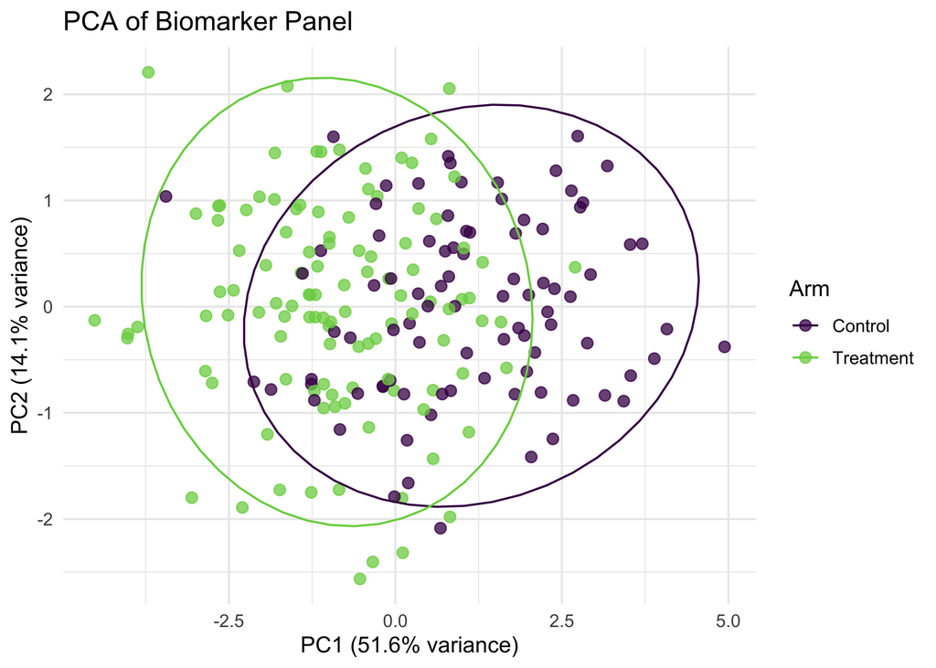

```r
biomarker_cols <- paste0("marker_", 1:6)
pca_fit_r <- prcomp(pca_data_r[, biomarker_cols], center = TRUE, scale. = TRUE)
var_explained_r <- (pca_fit_r$sdev^2) / sum(pca_fit_r$sdev^2) * 100

pc_scores_r <- as_tibble(pca_fit_r$x) %>%
  bind_cols(pca_data_r %>% select(arm, site))

ggplot(pc_scores_r, aes(x = PC1, y = PC2, color = arm)) +
  geom_point(size = 2.5, alpha = 0.75) +
  stat_ellipse(level = 0.95) +
  scale_color_viridis_d(end = 0.8) +
  labs(
    x = sprintf("PC1 (%.1f%% variance)", var_explained_r[1]),
    y = sprintf("PC2 (%.1f%% variance)", var_explained_r[2]),
    color = "Arm", title = "PCA of Biomarker Panel"
  ) +
  theme_minimal(base_size = 12)
```

> Scaling (`scale. = TRUE`) matters for PCA — without it, biomarkers on larger numeric scales dominate the components purely due to units.

### Biplot

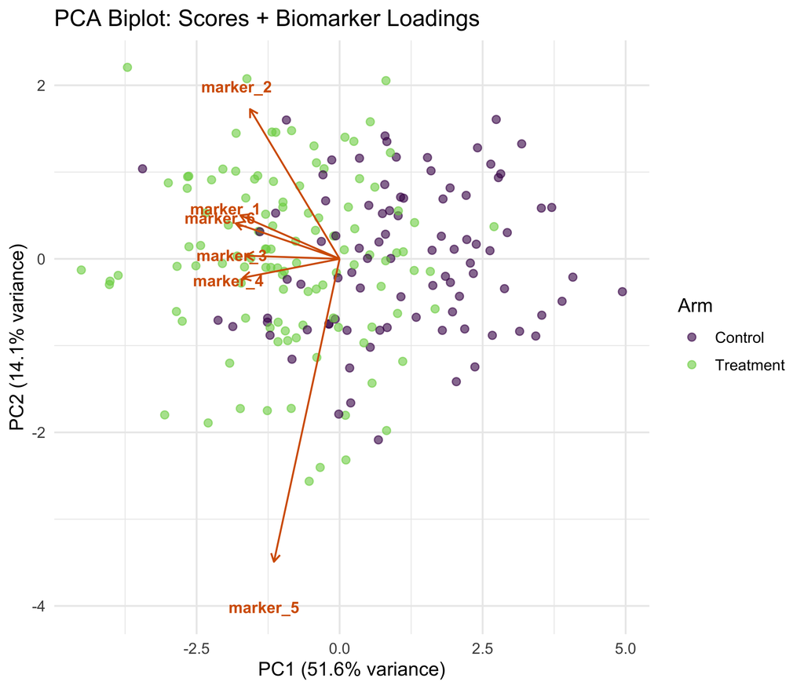

```r
loadings_r <- as_tibble(pca_fit_r$rotation[, 1:2], rownames = "biomarker")
scale_factor <- max(abs(pc_scores_r$PC1), abs(pc_scores_r$PC2)) * 0.8

ggplot() +
  geom_point(data = pc_scores_r, aes(x = PC1, y = PC2, color = arm), size = 2, alpha = 0.6) +
  geom_segment(data = loadings_r,
               aes(x = 0, y = 0, xend = PC1 * scale_factor, yend = PC2 * scale_factor),
               arrow = arrow(length = unit(0.2, "cm")), color = "#D55E00") +
  geom_text(data = loadings_r,
            aes(x = PC1 * scale_factor * 1.15, y = PC2 * scale_factor * 1.15, label = biomarker),
            color = "#D55E00", size = 3.5, fontface = "bold") +
  scale_color_viridis_d(end = 0.8) +
  labs(
    x = sprintf("PC1 (%.1f%% variance)", var_explained_r[1]),
    y = sprintf("PC2 (%.1f%% variance)", var_explained_r[2]),
    color = "Arm", title = "PCA Biplot: Scores + Biomarker Loadings"
  ) +
  theme_minimal(base_size = 12)
```

> Arrow direction shows which PCs a variable contributes to; arrow length shows how strongly. Arrows pointing the same direction = positively correlated variables; opposite directions = negatively correlated; ~90 degrees apart = little correlation.

### Scree plot

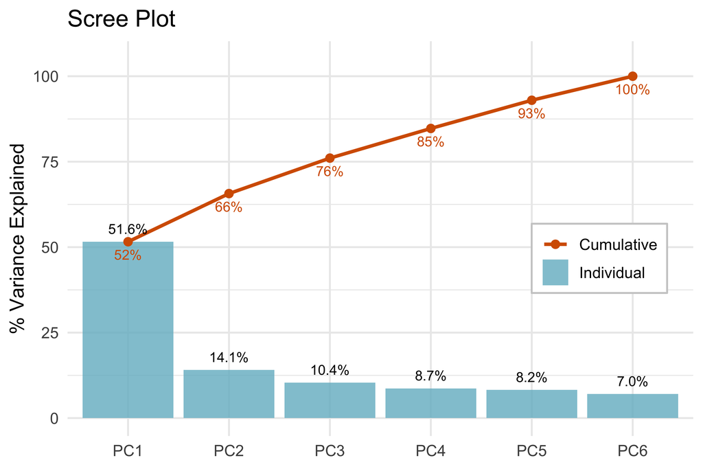

```r
scree_df_r <- tibble(
  PC = factor(paste0("PC", 1:length(var_explained_r)), levels = paste0("PC", 1:length(var_explained_r))),
  variance = var_explained_r,
  cumulative = cumsum(var_explained_r)
)

lvls <- c("Cumulative","Individual")

ggplot(scree_df_r, aes(x = PC)) +
  geom_col(aes(y = variance, fill = "Individual"), alpha = 0.8) +
  geom_line(aes(y = cumulative, group = 1, color = "Cumulative"),
            linewidth = 1) +
  geom_point(aes(y = cumulative, color = "Cumulative"), size = 2) +
  geom_text(aes(y = variance, label = sprintf("%.1f%%", variance)),
            vjust = -0.8, size = 3) +
  geom_text(aes(y = cumulative, label = sprintf("%.0f%%", cumulative)),
            vjust = 1.8, size = 3, color = "#D55E00") +
  scale_fill_manual(
    name = NULL, limits = lvls,
    values = c("Individual" = "#73b8ca", "Cumulative" = NA)
  ) +
  scale_color_manual(
    name = NULL, limits = lvls,
    values = c("Individual" = NA, "Cumulative" = "#D55E00")
  ) +
  scale_y_continuous(limits = c(0, 105)) +
  labs(x = NULL, y = "% Variance Explained", title = "Scree Plot") +
  theme_minimal(base_size = 12) +
  theme(
    legend.position = "inside",
    legend.position.inside = c(0.85, 0.45),
    legend.background = element_rect(fill = "white", color = "grey80"),
    legend.margin = margin(4, 6, 4, 6)
  )
```

### PCA notes

- Always report % variance explained in the axis label
- Color points by a meaningful metadata variable (condition, batch, cell type)
- For batch-effect checks, plot PCA colored by batch separately from biological condition
- A scree plot helps judge how many PCs actually matter

## 14. Multi-Panel Publication Figure

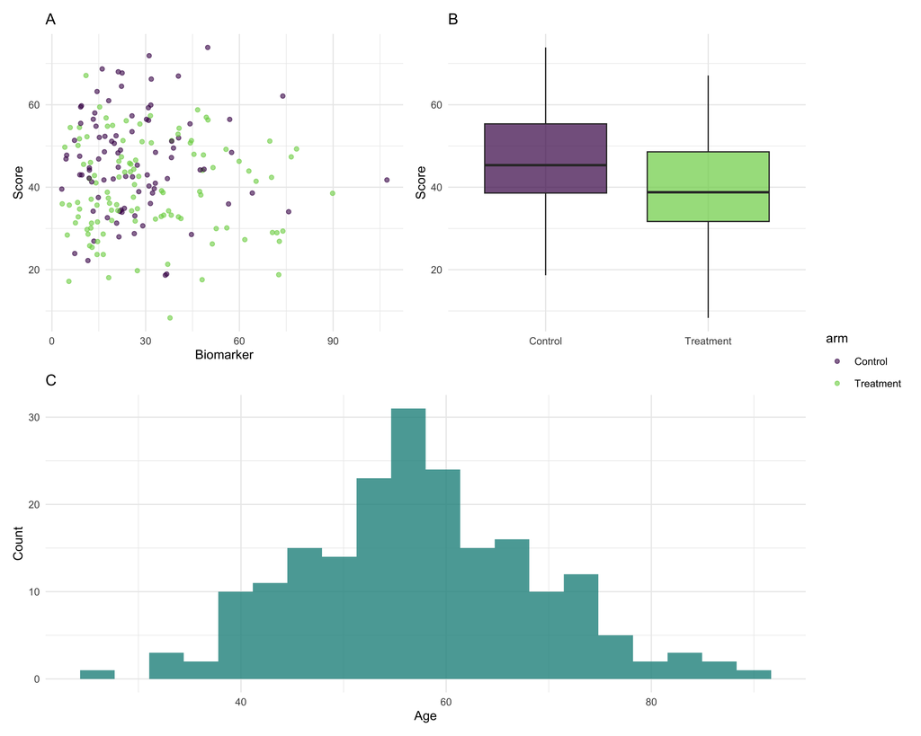

```r
library(patchwork)

p1 <- ggplot(clinical_r, aes(biomarker, followup_score, color = arm)) +
  geom_point(alpha = 0.6) + scale_color_viridis_d(end = 0.8) +
  theme_minimal(base_size = 10) + labs(title = "A", x = "Biomarker", y = "Score")

p2 <- ggplot(clinical_r, aes(arm, followup_score, fill = arm)) +
  geom_boxplot(alpha = 0.7) + scale_fill_viridis_d(end = 0.8) +
  theme_minimal(base_size = 10) + theme(legend.position = "none") +
  labs(title = "B", x = NULL, y = "Score")

p3 <- ggplot(clinical_r, aes(age)) +
  geom_histogram(bins = 20, fill = "#21908C", alpha = 0.8) +
  theme_minimal(base_size = 10) + labs(title = "C", x = "Age", y = "Count")

(p1 | p2) / p3 + plot_layout(guides = "collect")
```

```r
#p1 / p2 / p3 + plot_layout(guides = "collect")
```

## 15. Exporting for Publication

```r
ggsave("figure1_panel_R.pdf", plot = last_plot(),
       width = 7, height = 5, units = "in", dpi = 300)

ggsave("figure1_panel_R.tiff", plot = last_plot(),
       width = 7, height = 5, units = "in", dpi = 300, compression = "lzw")
```

## 16. Practice Exercise (20 min)

Using `clinical_trial_data.csv`, `longitudinal_data.csv`, and `pca_data.csv`, pick **one** and build a publication-ready version:

1. A Table 1 comparing baseline characteristics by arm
2. A density plot or ridgeline plot comparing a continuous variable across groups
3. A Kaplan-Meier curve comparing arms, with a risk table
4. A forest plot showing hazard ratios across 3+ subgroups
5. An ROC curve with AUC for biomarker predicting responder status
6. A line chart of score trajectory over time by arm
7. An annotated boxplot/mean±SD bar (with significance stars) comparing scores across site
8. A stacked bar chart of smoker status composition by site
9. A PCA score plot or biplot of the biomarker panel

**Checklist:**

- Colorblind-safe palette
- Axis labels with units
- Consistent theme
- Correct statistical test for the variable type
- Exported at 300 DPI in both PDF and PNG/TIFF

## Appendix: Color Palette Sources

### Viridis

Designed by Stéfan van der Walt and Nathaniel Smith for matplotlib in 2015; became matplotlib’s default colormap in version 2.0. Perceptually uniform, monotonically increasing luminance, legible under common color vision deficiencies. R: `viridis` package or `scale_color_viridis_d()`/`_c()`.

### Okabe-Ito

Proposed by Masataka Okabe and Kei Ito (2008), “Color Universal Design.” An empirically-chosen 8-color qualitative palette distinguishable across common forms of color blindness. Popularized by Bang Wong’s 2011 Nature Methods commentary (doi:10.1038/nmeth.1618). R: base R 4.0+ via `palette.colors()`, or ggplot2 >= 3.4.0 via `scale_color_okabeito()`.

**Rule of thumb:** viridis for continuous data, Okabe-Ito for categorical data.

> Materials for this code document were drafted with assistance from Claude (Anthropic) and reviewed and edited by the instructor prior to teaching.